# Analyse des données

Waï

2023-06-27

## Présentation

Analyse d’un dataset avec lanagage R dans le cadre de l’évaluation du module BigData

## Exploration du dataset

```r
# visualisation des 5 premières lignes
head(data, 5)
```

```
## # A tibble: 5 × 13
##    ...1   age workclass education    marit…¹ occup…² relat…³ race  sex   capit…⁴
##   <dbl> <dbl>     <dbl> <chr>        <chr>     <dbl> <chr>   <chr> <chr>   <dbl>
## 1     1    90        NA HS-grad      Widowed      NA Not-in… White Fema…       0
## 2     2    82         5 HS-grad      Widowed       5 Not-in… White Fema…       0
## 3     3    66        NA Some-college Widowed      NA Unmarr… Black Fema…       0
## 4     4    54         5 7th-8th      Divorc…       8 Unmarr… White Fema…       0
## 5     5    41         5 Some-college Separa…      11 Own-ch… White Fema…       0
## # … with 3 more variables: capital.loss <dbl>, hours.per.week <dbl>,
## #   income <chr>, and abbreviated variable names ¹marital.status, ²occupation,
## #   ³relationship, ⁴capital.gain
```

```r
#dimension
dim(data)
```

```
## [1] 32561    13
```

Le dataset a 32561 lignes et 13 colonnes(variables)

```r
summary(data)
```

```
##       ...1            age          workclass     education
##  Min.   :    1   Min.   :17.00   Min.   :2.0    Length:32561
##  1st Qu.: 8141   1st Qu.:28.00   1st Qu.:5.0    Class :character
##  Median :16281   Median :37.00   Median :5.0    Mode  :character
##  Mean   :16281   Mean   :38.58   Mean   :5.1
##  3rd Qu.:24421   3rd Qu.:48.00   3rd Qu.:5.0
##  Max.   :32561   Max.   :90.00   Max.   :9.0
##                                  NA's   :1836
##  marital.status       occupation     relationship           race
##  Length:32561       Min.   : 2.000   Length:32561       Length:32561
##  Class :character   1st Qu.: 4.000   Class :character   Class :character
##  Mode  :character   Median : 8.000   Mode  :character   Mode  :character
##                     Mean   : 7.967
##                     3rd Qu.:11.000
##                     Max.   :15.000
##                     NA's   :1843
##      sex             capital.gain    capital.loss    hours.per.week
##  Length:32561       Min.   :    0   Min.   :   0.0   Min.   : 1.00
##  Class :character   1st Qu.:    0   1st Qu.:   0.0   1st Qu.:40.00
##  Mode  :character   Median :    0   Median :   0.0   Median :40.00
##                     Mean   : 1078   Mean   :  87.3   Mean   :40.44
##                     3rd Qu.:    0   3rd Qu.:   0.0   3rd Qu.:45.00
##                     Max.   :99999   Max.   :4356.0   Max.   :99.00
##
##     income
##  Length:32561
##  Class :character
##  Mode  :character
##
##
##
##
```

## Valeurs manquantes

```r
#Compter le nombre de valeurs manquantes dans chacune des colonnes
sapply(data,function(x) sum(is.na(x)))
```

```
##           ...1            age      workclass      education marital.status
##              0              0           1836              0              0
##     occupation   relationship           race            sex   capital.gain
##           1843              0              0              0              0
##   capital.loss hours.per.week         income
##              0              0              0
```

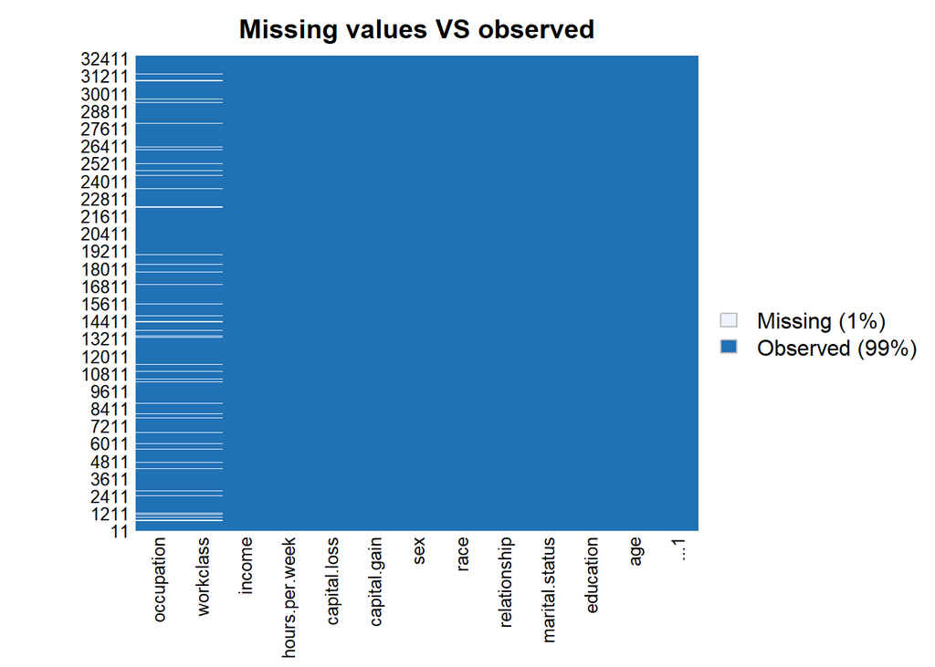

```r
#Afficher un graph avec les valeurs manquantes vs les valeurs observées

missmap(data, main = "Missing values VS observed")
```

On remarque que le dataset possède des valeurs manquantes qui sont très négligeables.

## 4 Etude des variables sexe et income

```r
table(data$income, data$sex)
```

```
##
##         Female  Male
##   <=50K   9592 15128
##   >50K    1179  6662
```

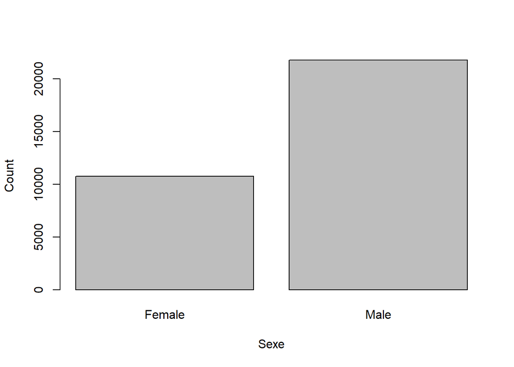

```r
barplot(table(data$sex), xlab="Sexe", ylab="Count")
```

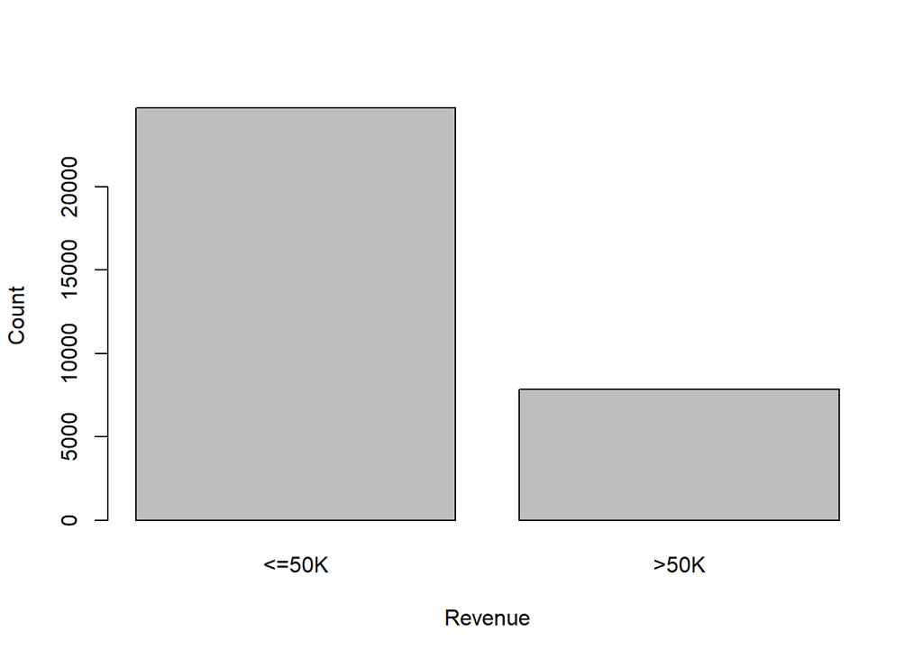

```r
barplot(table(data$income), xlab="Revenue", ylab="Count")
```

On constate que le dataset a plus d’individus de sexe masculin que feminin et qu’il y’a plus d’individus qui ont des revenus inférieur à 50k.

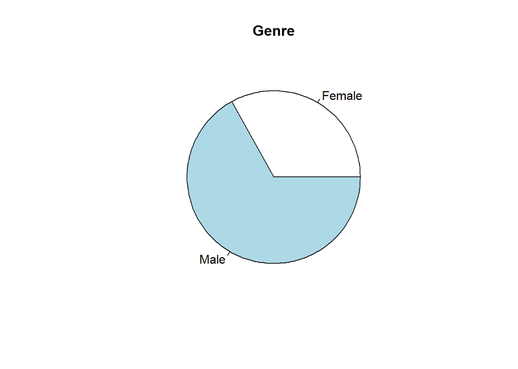

```r
pie(table(data$sex), main = "Genre")
```

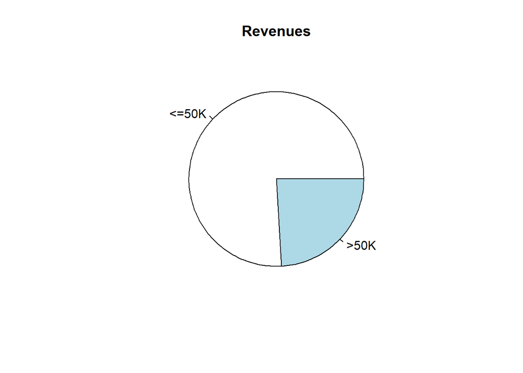

```r
pie(table(data$income), main = "Revenues")
```

## 5- Etude des variables : Age et capital loss

```r
summary(data$age)
```

```
##    Min. 1st Qu.  Median    Mean 3rd Qu.    Max.
##   17.00   28.00   37.00   38.58   48.00   90.00
```

```r
summary(data$capital.loss)
```

```
##    Min. 1st Qu.  Median    Mean 3rd Qu.    Max.
##     0.0     0.0     0.0    87.3     0.0  4356.0
```

L’âge minimal de notre dataset est 17 ans et le maximum est 90. L’âge moyen des individus est entre 38 et 39 ans.

On constate qu’il ya une présence faible de valeurs au niveau de la variable “capital_loss” car plus de la moitié des observations est nulle

```r
#calcul de la covariance
cov(x=data$age, y=data$capital.loss)
```

```
## [1] 317.5607
```

La covariance est non nulle et positif donc les variables “age” et “capital” sont dépendants et varient dans le même sens

## 6- Données abérrantes des variables précedentes

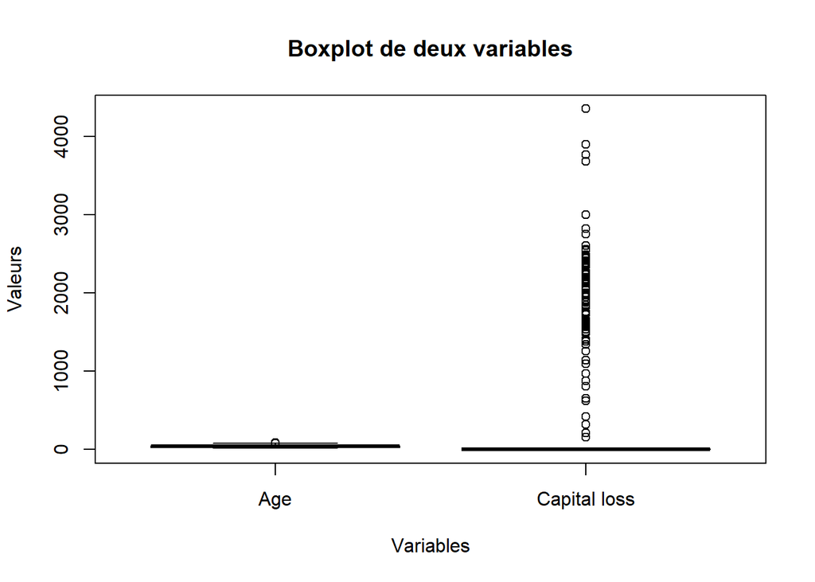

```r
boxplot(data$age, data$capital.loss, names = c("Age", "Capital loss"),
        xlab = "Variables", ylab = "Valeurs", main = "Boxplot de deux variables")
```

Il existe plus de valeurs abérrantes dans la variable “capital_loss” que dans “age”

## 8 Les 9 premiers individus les plus âgés

```r
sorted_data <- data %>% arrange(age,)
tail(x = sorted_data, 9)
```

```
## # A tibble: 9 × 13
##    ...1   age workclass education marital.…¹ occup…² relat…³ race  sex   capit…⁴
##   <dbl> <dbl>     <dbl> <chr>     <chr>        <dbl> <chr>   <chr> <chr>   <dbl>
## 1 21421    90         5 7th-8th   Married-c…       8 Husband White Male        0
## 2 22167    90         5 Masters   Married-c…      11 Wife    White Fema…       0
## 3 23591    90         5 Bachelors Never-mar…      11 Not-in… Asia… Male        0
## 4 25340    90        NA 1st-4th   Widowed         NA Not-in… Black Fema…       0
## 5 26260    90        NA 7th-8th   Separated       NA Not-in… White Fema…       0
## 6 29000    90         2 HS-grad   Married-c…       4 Husband White Male        0
## 7 31219    90         5 HS-grad   Married-c…       8 Husband White Male        0
## 8 31800    90        NA HS-grad   Married-c…      NA Husband White Male        0
## 9 32306    90         5 HS-grad   Widowed          2 Unmarr… White Fema…       0
## # … with 3 more variables: capital.loss <dbl>, hours.per.week <dbl>,
## #   income <chr>, and abbreviated variable names ¹marital.status, ²occupation,
## #   ³relationship, ⁴capital.gain
```

## 9 Calcul de la moyenne des âges e, fonction des revenus

```r
moyenne <- aggregate(data$age, by=list(data$income), FUN=mean, na.rm=TRUE)
moyenne
```

```
##   Group.1        x
## 1   <=50K 36.78374
## 2    >50K 44.24984
```

## 10 Test d’indépendance : Sexe et Income

Le test Khi-deux qui permet de connaitre la relation existante entre deux variables qualitatives avec chisp.test ** H0 : les deux variables sont indépendante si p-value >=5 ** H1 : les deux variables sont dépendantes

Il s’agit de traiter La variable à expliquer (dépendante) Y c’est Income La variable explicative (indépendante) X c’est Sexe

```r
table(data$income, data$sex)
```

```
##
##         Female  Male
##   <=50K   9592 15128
##   >50K    1179  6662
```

```r
chisq.test(x = data$sex, y = data$income)
```

```
##
##  Pearson's Chi-squared test with Yates' continuity correction
##
## data:  data$sex and data$income
## X-squared = 1517.8, df = 1, p-value < 2.2e-16
```

Comme la p-value est inférieure à 5 alors les deux variables sont dépendance c’est dire que la variable sexe influence significativement la variable income

## 11 Test d’indépendance entre les variables income et sexe

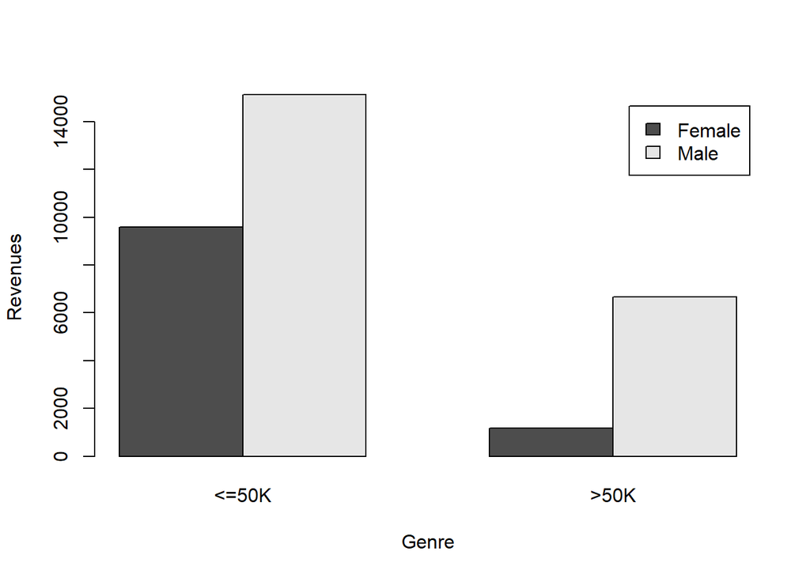

```r
# Supposons que vous ayez deux variables qualitatives : "variable1" et "variable2"
table_data <- table(data$sex, data$income)
barplot(table_data, beside = TRUE, legend = TRUE, xlab = "Genre", ylab = "Revenues")
```

## 12 Test d’indépendance entre les varaibles age et capital loss

```r
#calcul du coefficient de corrélation
cor(x=data$age, y=data$capital.loss)
```

```
## [1] 0.05777454
```